# STAT 510: Spatiotemporal Stats

Spatiotemporal Stats Lab 1

Prof. Taylor-Rodriguez

```r
knitr::opts_chunk$set(echo = TRUE,cache = TRUE)
library(STRbook)
library(ggplot2)
library(dplyr)
library(tidyr)
library(tidyverse)
library(sp)
library(spacetime)
library(lubridate)
```

## Let’s get the Lab started

We’ll be working with the following datasets

# Data Wrangling

## Data Wrangling and Visualization

First, let’s load into R, combine and rearrange into long format these datasets.

This can help summarize and visualize the data

## Loading data tables into R

```r
#locations
locs <- read.table(system.file("extdata","Stationinfo.dat",
                               package = "STRbook"),
                   col.names = c("id", "lat", "lon"))

#times
Times <- read.table(system.file("extdata","Times_1990.dat",
                                package = "STRbook"),
                    col.names = c("julian", "year", "month", "day"))

#Actual data files
Tmax <- read.table(system.file("extdata", "Tmax_1990.dat",
                               package = "STRbook"))
Tmin <- read.table(system.file("extdata", "Tmin_1990.dat",
                               package = "STRbook"))
Precip <- read.table(system.file("extdata", "Precip_1990.dat",
                               package = "STRbook"))

#name columns (station id's) in data tables
names(Tmax) <- names(Tmin) <- names(Precip) <- locs$id
```

## Convert data into long format

```r
#using dplyr functions:
Tmax_long <- bind_cols(Times,Tmax) %>% #add time stamps to Tmax
  gather(key="id", value="values",
         -julian, -year, -month, -day) %>% #make into long format
  mutate(proc="Tmax") #add variable label

head(Tmax_long,4)
```

|  | julian | year | month | day | id | values | proc |
| --- | --- | --- | --- | --- | --- | --- | --- |
| 1 | 726834 | 1990 | 1 | 1 | 3804 | 35 | Tmax |
| 2 | 726835 | 1990 | 1 | 2 | 3804 | 42 | Tmax |
| 3 | 726836 | 1990 | 1 | 3 | 3804 | 49 | Tmax |
| 4 | 726837 | 1990 | 1 | 4 | 3804 | 59 | Tmax |

the `gather` function has been replaced by `pivot_long`… but for now we’ll stick to what they use in the book

## Convert data into long format

```r
#rinse and repeat with Tmin and Precip
Tmin_long <- bind_cols(Times,Tmin) %>%
  gather(key="id", value="values", -julian, -year, -month, -day) %>%
  mutate(proc="Tmin")

Precip_long <- bind_cols(Times,Precip) %>%
  gather(key="id", value="values", -julian, -year,
         -month, -day)  %>%
  mutate(proc="Precip")
```

## Combine data and remove NA’s

```r
#combine all data into single
NOAA_df_1990 <- bind_rows(Tmax_long,
                          Tmin_long,
                          Precip_long)
#remove NA's
NOAA_df_1990 <- NOAA_df_1990 %>%
  filter(values>-9999 & (proc%in%c("Tmax","Tmin")) |
           values>-99 & proc=="Precip")
#remove previous datasets
rm(list=c("Tmax_long","Tmin_long","Precip_long"))
```

## Some simple data summaries

```r
#overall means by variable ("proc" in data)
summ <- NOAA_df_1990 %>%
  group_by(proc) %>%
  summarise(proc_means=mean(values))
head(summ)
```

| proc | proc_means |
| --- | --- |
| Precip | 0.1172877 |
| Tmax | 65.5229423 |
| Tmin | 45.3837542 |

## Some simple data summaries

```r
#yearly means by variable
summ <- NOAA_df_1990 %>%
  group_by(proc,year) %>%
  summarise(proc_means=mean(values))
head(summ,5)
```

| proc | year | proc_means |
| --- | --- | --- |
| Precip | 1990 | 0.1260259 |
| Precip | 1991 | 0.1158044 |
| Precip | 1992 | 0.1106477 |
| Precip | 1993 | 0.1164913 |
| Tmax | 1990 | 67.3873718 |

## More involved summaries

### Mean number of dry days in June each year by station

```r
summ <- NOAA_df_1990 %>%
  filter(proc=="Precip",month==6,values==0) %>%
  group_by(id,year,month) %>%
  summarise(numdry=n())
head(summ)
```

| id | year | month | numdry |
| --- | --- | --- | --- |
| 13865 | 1990 | 6 | 23 |
| 13865 | 1991 | 6 | 19 |
| 13865 | 1992 | 6 | 20 |
| 13865 | 1993 | 6 | 23 |
| 13866 | 1990 | 6 | 19 |
| 13866 | 1991 | 6 | 22 |

## More involved summaries

### Mean number of dry days in June each year

```r
summ <- summ %>%
  ungroup() %>%
  group_by(year,month) %>%
  summarise(mu_noprecip=mean(numdry)) %>%
  select(-month)
head(summ)
```

| year | mu_noprecip |
| --- | --- |
| 1990 | 20.51111 |
| 1991 | 22.21481 |
| 1992 | 19.68939 |
| 1993 | 18.67424 |

## Combining datasets using *keys*

Let’s add the station location information to the combined data

```r
locs <- locs %>% mutate(id=as.character(id))
NOAA_df_1990 <- NOAA_df_1990 %>%
  left_join(locs,by="id")

head(NOAA_df_1990,5)
```

|  | julian | year | month | day | id | values | proc | lat | lon |
| --- | --- | --- | --- | --- | --- | --- | --- | --- | --- |
| 1 | 726834 | 1990 | 1 | 1 | 3804 | 35 | Tmax | 39.35 | -81.43333 |
| 2 | 726835 | 1990 | 1 | 2 | 3804 | 42 | Tmax | 39.35 | -81.43333 |
| 3 | 726836 | 1990 | 1 | 3 | 3804 | 49 | Tmax | 39.35 | -81.43333 |
| 4 | 726837 | 1990 | 1 | 4 | 3804 | 59 | Tmax | 39.35 | -81.43333 |
| 5 | 726838 | 1990 | 1 | 5 | 3804 | 41 | Tmax | 39.35 | -81.43333 |

`left_join` keeps all observations in left dataset and finds matches according to the *key* (here *“id”*) in the dataset on the right hand side. Other options available.

## Create *date* variable from *year*, *month*, *day*

```r
NOAA_df_1990 <- NOAA_df_1990 %>%
  unite("date",year,month,day,remove=F) %>%
  mutate(date=ymd(date))

head(NOAA_df_1990,5)
```

|  | julian | date | year | month | day | id | values | proc | lat | lon |
| --- | --- | --- | --- | --- | --- | --- | --- | --- | --- | --- |
| 1 | 726834 | 1990-01-01 | 1990 | 1 | 1 | 3804 | 35 | Tmax | 39.35 | -81.43333 |
| 2 | 726835 | 1990-01-02 | 1990 | 1 | 2 | 3804 | 42 | Tmax | 39.35 | -81.43333 |
| 3 | 726836 | 1990-01-03 | 1990 | 1 | 3 | 3804 | 49 | Tmax | 39.35 | -81.43333 |
| 4 | 726837 | 1990-01-04 | 1990 | 1 | 4 | 3804 | 59 | Tmax | 39.35 | -81.43333 |
| 5 | 726838 | 1990-01-05 | 1990 | 1 | 5 | 3804 | 41 | Tmax | 39.35 | -81.43333 |

# Visualization

## Empirical Spatial Means Plot

### For geostatistical data

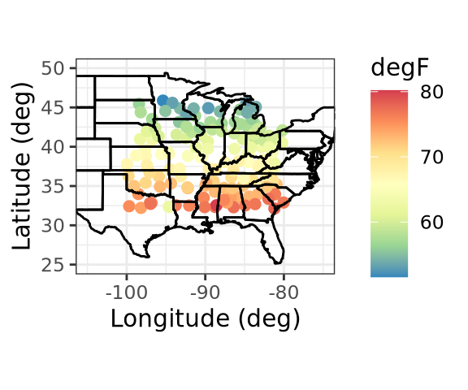

```r
NOAA_df_1990 %>%
  filter(proc=="Tmax") %>%
  group_by(id,lon,lat) %>%
  summarise(z=mean(values)) %>%
  ggplot() +
  geom_point(aes(x=lon,y=lat,colour=z),size=2) +
  col_scale(name = "degF") +
  xlab("Longitude (deg)") +
  ylab("Latitude (deg)") +
  geom_path(data = map_data("state"),# state boundaries
            aes(x = long, y = lat, group = group)) +
  coord_fixed(xlim = c(-105, -75),
              ylim= c(25,50)) +
  theme_bw()
```

## Empirical Spatial Means Plot (By Year)

### For geostatistical data

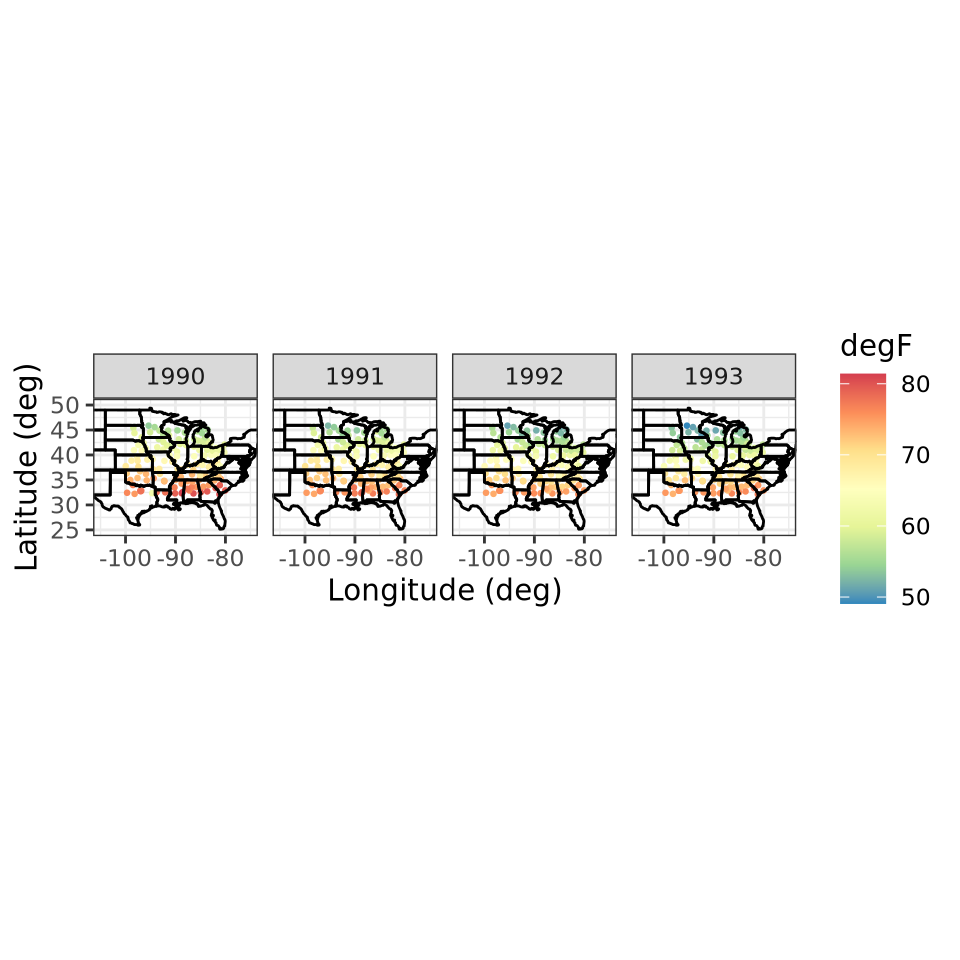

```r
NOAA_df_1990 %>%
  filter(proc=="Tmax") %>%
  group_by(id,lon,lat,year) %>%
  summarise(z=mean(values)) %>%
  ggplot() +
  geom_point(aes(x=lon,y=lat,colour=z),size=0.5) +
  col_scale(name = "degF") +
  xlab("Longitude (deg)") +
  ylab("Latitude (deg)") +
  geom_path(data = map_data("state"),# state boundaries
            aes(x = long, y = lat, group = group)) +
  facet_grid(.~year) +
  coord_fixed(xlim = c(-105, -75),
              ylim= c(25,50)) +
  theme_bw()
```

## Empirical Spatial Covariances and Plots

### For geostatistical data

Let’s work with the Tmax data between May and September of 1993

```r
Tmax_long <- NOAA_df_1990 %>% # now subset the data
  filter(proc == "Tmax" &     # only max temperature
           month %in% 5:9 &   # May to September
           year == 1993) %>%  # year 1993
  mutate(t=as.integer(julian-min(julian-1))) #create time variable
```

## Empirical Spatial Covariances and Plots

But first, de-trend the data

```r
lm1 <- lm(values ~ lat + t + I(t^2), # fit a linear model
          data = Tmax_long)
Tmax_long$residuals <- residuals(lm1) # store the residuals
```

Extract the spatial locations

```r
spat_df <- filter(Tmax_long, t == 1) %>% # lon/lat coords of stations
  select(lon, lat) %>% # select lon/lat only
  arrange(lon, lat) # sort ascending by lon/lat
m <- length(unique(Tmax_long$id)) # number of stations
```

## Empirical Spatial Covariances and Plots

Put data in *space-wide* format

```r
X <- select(Tmax_long, lon, lat, residuals, t) %>% # select columns
spread(t, residuals) %>% select(-lon, -lat) %>% t()
```

Calculate lag-0 and lag-1 covariance matrices (use `complete.obs`)

```r
Lag0_cov <- cov(X, use = 'complete.obs')
Lag1_cov <- cov(X[-1, ], X[-nrow(X),],use = 'complete.obs')
```

## Empirical Spatial Covariances and Plots

```r
# assign an index to each station
spat_df$n <- 1:nrow(spat_df)

# range of lon coordinates
lim_lon <- range(spat_df$lon)

# create 4 long. strip boundaries
lon_strips <- seq(lim_lon[1],lim_lon[2],length = 5)
spat_df$lon_strip <- cut(spat_df$lon, # bin the lon into
                         lon_strips, # their respective bins
                         labels = FALSE, # don't assign labels
                         include.lowest = TRUE) # include edges
```

### Lag 0 covariances

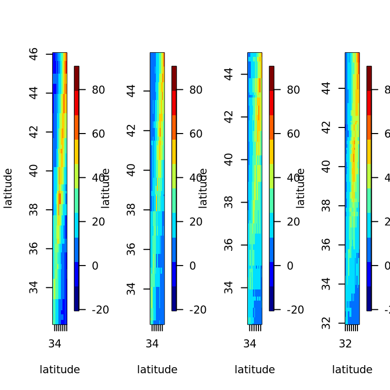

```r
par(mfrow=c(1,4))
plot_cov_strips(Lag0_cov, spat_df) # plot the lag-0 matrices
```

### Lag 1 covariances

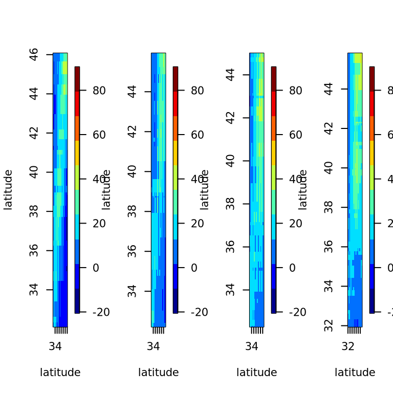

```r
par(mfrow=c(1,4))
plot_cov_strips(Lag1_cov, spat_df) # plot the lag-1 matrices
```

## Empirical Spatial Means Plot

### For areal data

```r
data("BEA", package = "STRbook") #income data
head(BEA %>% select(-Description), 3)
```

|  | NAME10 | X1970 | X1980 | X1990 |
| --- | --- | --- | --- | --- |
| 6 | Adair, MO | 2723 | 7399 | 12755 |
| 9 | Andrew, MO | 3577 | 7937 | 15059 |
| 12 | Atchison, MO | 3770 | 5743 | 14748 |

```r
data("MOcounties", package = "STRbook")  #county geo data
```

## Empirical Spatial Means Plot

### For areal data

Join MO county boundary data with income

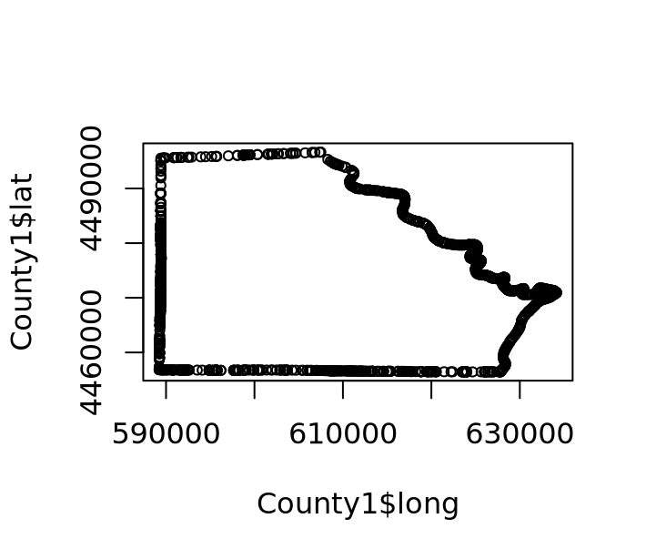

```r
MOcounties <- left_join(MOcounties, BEA, by = "NAME10")

County1 <- filter(MOcounties, NAME10 == "Clark, MO")
plot(County1$long, County1$lat, cex=0.7)
```

## Empirical Spatial Means Plot

### For areal data

```r
ggplot(MOcounties) +
  geom_polygon(aes(x = long, y = lat, # county boundary
                   group = NAME10, # county group
                   fill = log(X1970))) + # log of income
  geom_path(aes(x = long, y = lat, # county boundary
                group = NAME10)) + # county group
  fill_scale(limits = c(7.5,10.2),name = "log($)") +
  coord_fixed() + ggtitle("1970") + # annotations
  xlab("x (m)") + ylab("y (m)") + theme_bw()
```

## Empirical Spatial Means Plot

### For areal data

[figure not shown]

## Hovmoller Plot

```r
lim_lat <- range(Tmax_long$lat)  # latitude range
lim_t <- range(Tmax_long$t) # time range
lat_axis <- seq(lim_lat[1], # latitude axis
                lim_lat[2],
                length=25)
t_axis <- seq(lim_t[1], # time axis
              lim_t[2],
              length=100)
lat_t_grid <- expand.grid(lat = lat_axis,
                          t = t_axis)
```

```r
Tmax_grid <- Tmax_long
dists <- abs(outer(Tmax_long$lat, lat_axis, "-"))
Tmax_grid$lat <- lat_axis[apply(dists, 1, which.min)]
```

```r
 Tmax_lat_Hov <- Tmax_grid %>% group_by(lat, t) %>%
  summarise(z = mean(values))
```

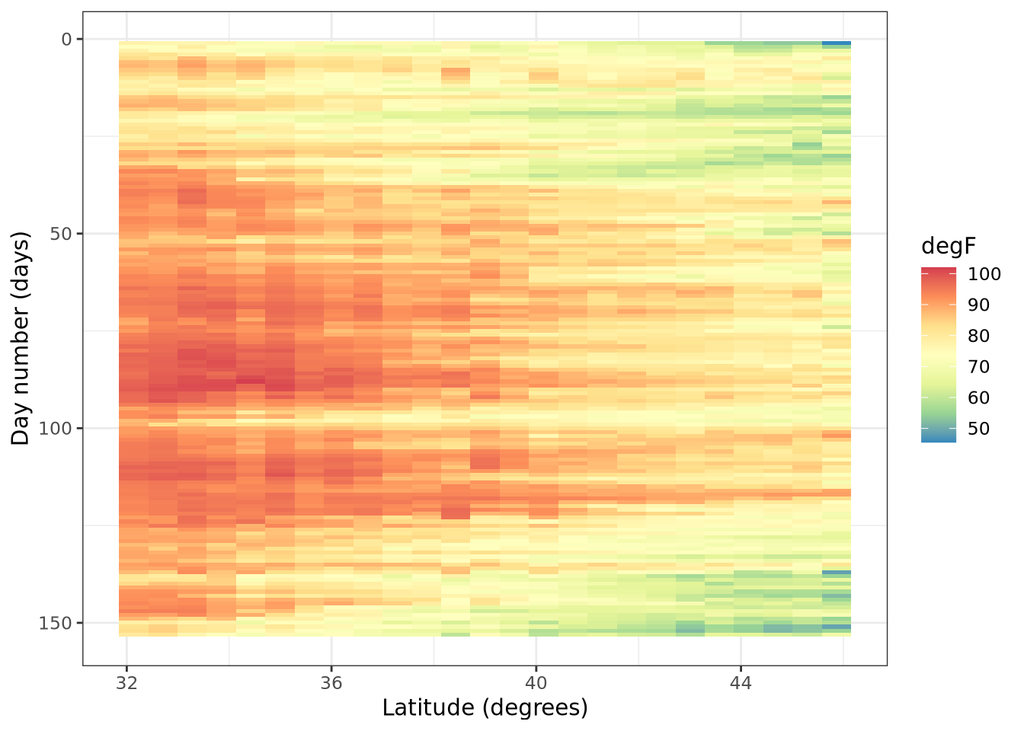

```r
ggplot(Tmax_lat_Hov) + # take data
  geom_tile(aes(x = lat, y = t, fill = z)) + # plot
  fill_scale(name = "degF") +
  scale_y_reverse() +
  ylab("Day number (days)") +
  xlab("Latitude (degrees)") +
  theme_bw()
```

## On your own

For the SST data loaded using the code below:

1. generate a data frame with the Empirical Spatial Means per decade (1970-1979, 1980-1989, 1990-2002) and plot them with one panel per decade
2. generate a spatial plot for the **yearly** SST 95th quantile for the years 1980, 1990, 2000 having one panel per year
3. Obtain a Hovmoller plot for these data
4. Calculate the EOFs for the *SST* dataset. Replicate the figures in pages 44-45 using the R function `eigen` (not `svd`) and `ggplot2::geom\_tile` and interpret them. How many EOFs would you retain?

```r
data("SSTlandmask", package = "STRbook")
data("SSTlonlat", package = "STRbook")
data("SSTdata", package = "STRbook")

#remove years that are not complete
rm_rows <- which(SSTlandmask == 1)
SSTdata <- SSTdata[-rm_rows, 1:396]
```